# Project 2 - Classification

Siri Bafna

# Census Income Data Analysis

Source: UCI Machine Learning Repository

Link: http://archive.ics.uci.edu/ml/datasets/Census+Income

#### Factoring character variables, cleaning NA’s, reading in data

I began data cleaning by removing the column “fnlwgt” because it had no relationship to income.

Since the data had nulls as ‘?’ instead of NA, I ran the gsub() function on the dataset, replacing ’?’s with NA’s. I then used the is.na() to remove any bad data from the data set. The columns with null data included workclass, occupation and native_country.

I then factored many of the variables as they were character based, not integer and ended my data cleaning by verifying my changes using str().

```r
censusIncome <- read.csv("/Users/siri/Downloads/CensusIncome.csv", header=TRUE)
censusIncome <- censusIncome[,c(1,2,4,6,7,8, 9, 10, 11, 12, 13, 14, 15)]
censusIncome$workclass <- gsub("?", NA, censusIncome$workclass, fixed = TRUE);
censusIncome$native_country <- gsub("?", NA, censusIncome$native_country, fixed = TRUE);

censusIncome$occupation <- gsub("?", NA, censusIncome$occupation, fixed = TRUE);
censusIncome <- censusIncome[!is.na(censusIncome$workclass),]
censusIncome <- censusIncome[!is.na(censusIncome$occupation),]
censusIncome <- censusIncome[!is.na(censusIncome$native_country),]

censusIncome$workclass <- as.factor(censusIncome$workclass)
censusIncome$education <- as.factor(censusIncome$education)
censusIncome$marital_status <- as.factor(censusIncome$marital_status)
censusIncome$occupation <- as.factor(censusIncome$occupation)
censusIncome$relationship <- as.factor(censusIncome$relationship)
censusIncome$race <- as.factor(censusIncome$race)
censusIncome$sex <- as.factor(censusIncome$sex)
censusIncome$native_country <- as.factor(censusIncome$native_country)
censusIncome$income_level <- as.factor(censusIncome$income_level)

str(censusIncome) # data exploration function # 1
```

```
'data.frame':   45222 obs. of  13 variables:
 $ age           : int  39 50 38 53 28 37 49 52 31 42 ...
 $ workclass     : Factor w/ 7 levels "Federal-gov",..: 6 5 3 3 3 3 3 5 3 3 ...
 $ education     : Factor w/ 16 levels "10th","11th",..: 10 10 12 2 10 13 7 12 13 10 ...
 $ marital_status: Factor w/ 7 levels "Divorced","Married-AF-spouse",..: 5 3 1 3 3 3 4 3 5 3 ...
 $ occupation    : Factor w/ 14 levels "Adm-clerical",..: 1 4 6 6 10 4 8 4 10 4 ...
 $ relationship  : Factor w/ 6 levels "Husband","Not-in-family",..: 2 1 2 1 6 6 2 1 2 1 ...
 $ race          : Factor w/ 5 levels "Amer-Indian-Eskimo",..: 5 5 5 3 3 5 3 5 5 5 ...
 $ sex           : Factor w/ 2 levels "Female","Male": 2 2 2 2 1 1 1 2 1 2 ...
 $ capital_gain  : num  2174 0 0 0 0 ...
 $ capital_loss  : num  0 0 0 0 0 0 0 0 0 0 ...
 $ hours_per_week: num  40 13 40 40 40 40 16 45 50 40 ...
 $ native_country: Factor w/ 41 levels "Cambodia","Canada",..: 39 39 39 39 5 39 23 39 39 39 ...
 $ income_level  : Factor w/ 2 levels "<=50K",">50K": 1 1 1 1 1 1 1 2 2 2 ...
```

#### Divide into train and test

```r
set.seed(1234)
i <- sample(1:nrow(censusIncome), .6*nrow(censusIncome), replace=FALSE)
train <- censusIncome[i,]
test <- censusIncome[-i,]
```

## Data Exploration

```r
# data exploration function # 2
per_no_capital_gain <- sum(censusIncome$capital_gain==0)/length(censusIncome$capital_gain)
print("Percentage of Instances Without Capital Gain")
```

```
[1] "Percentage of Instances Without Capital Gain"
```

```r
print(per_no_capital_gain)
```

```
[1] 0.9161912
```

```r
print("Division of Income based on Sex")
```

```
[1] "Division of Income based on Sex"
```

```r
table(censusIncome$sex) # data exploration function # 3
```

```
Female   Male
 14695  30527
```

#### Plots For Data Exploration

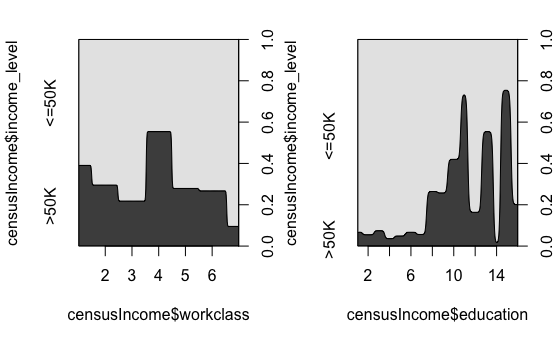

```r
par(mfrow=c(1, 2))
cdplot(censusIncome$income_level~censusIncome$workclass)
cdplot(censusIncome$income_level~censusIncome$education)
```

As shown below in all of my models, my feature consisted of all the columns except native_country. This is because native_country contains more than 32 levels and therefore is unable to be modeled with. All my other features were chosen because they were obviously related to income (workclass, education, occupation, race, sex, etc) and all contribute to it, as known theoretically.

## Logistic Regression - Algorithm # 1

```r
glm1 <- glm(income_level~.-native_country, data=train, family=binomial)
```

```
glm.fit: fitted probabilities numerically 0 or 1 occurred
```

```r
summary(glm1) # data exploration function # 4
```

```
Call:
glm(formula = income_level ~ . - native_country, family = binomial,
    data = train)

Deviance Residuals:
    Min       1Q   Median       3Q      Max
-5.1878  -0.5103  -0.1879  -0.0255   3.6292

Coefficients:
                                      Estimate Std. Error z value
(Intercept)                         -6.839e+00  4.398e-01 -15.551
age                                  2.601e-02  1.782e-03  14.591
workclassLocal-gov                  -6.450e-01  1.188e-01  -5.429
workclassPrivate                    -4.707e-01  9.832e-02  -4.788
workclassSelf-emp-inc               -3.557e-01  1.305e-01  -2.726
workclassSelf-emp-not-inc           -1.044e+00  1.156e-01  -9.034
workclassState-gov                  -7.809e-01  1.316e-01  -5.932
workclassWithout-pay                -8.698e-01  8.391e-01  -1.037
education11th                       -5.727e-02  2.310e-01  -0.248
education12th                        4.781e-01  2.779e-01   1.720
education1st-4th                    -6.945e-01  4.871e-01  -1.426
education5th-6th                    -8.873e-01  3.900e-01  -2.275
education7th-8th                    -5.300e-01  2.521e-01  -2.102
education9th                        -3.869e-01  2.835e-01  -1.365
educationAssoc-acdm                  1.278e+00  1.917e-01   6.666
educationAssoc-voc                   1.178e+00  1.846e-01   6.383
educationBachelors                   1.891e+00  1.720e-01  10.998
educationDoctorate                   2.775e+00  2.336e-01  11.881
educationHS-grad                     7.408e-01  1.672e-01   4.431
educationMasters                     2.201e+00  1.827e-01  12.044
educationPreschool                  -1.909e+01  9.942e+01  -0.192
educationProf-school                 2.736e+00  2.215e-01  12.353
educationSome-college                1.140e+00  1.698e-01   6.715
marital_statusMarried-AF-spouse      1.979e+00  6.262e-01   3.161
marital_statusMarried-civ-spouse     2.063e+00  2.862e-01   7.208
marital_statusMarried-spouse-absent  1.117e-01  2.421e-01   0.461
marital_statusNever-married         -5.057e-01  9.605e-02  -5.265
marital_statusSeparated             -1.160e-01  1.864e-01  -0.622
marital_statusWidowed                1.109e-02  1.722e-01   0.064
occupationArmed-Forces               2.684e-01  1.187e+00   0.226
```

[output cut: 76 more lines]

```
raceWhite                            0.07131 .
sexMale                             3.35e-15 ***
capital_gain                         < 2e-16 ***
capital_loss                         < 2e-16 ***
hours_per_week                       < 2e-16 ***
---
Signif. codes:  0 ‘***’ 0.001 ‘**’ 0.01 ‘*’ 0.05 ‘.’ 0.1 ‘ ’ 1

(Dispersion parameter for binomial family taken to be 1)

    Null deviance: 30249  on 27132  degrees of freedom
Residual deviance: 17501  on 27078  degrees of freedom
AIC: 17611

Number of Fisher Scoring iterations: 13
```

#### Accuracy and Predictions for Logistic Regression

```r
probs <- predict(glm1, newdata=test, type="response")
pred <- ifelse(probs>.5, 2, 1)

table(test$income_level, probs >= .5) # data exploration function # 5
```

```
        FALSE  TRUE
  <=50K 12581   963
  >50K   1825  2720
```

```r
acc <- mean(pred==as.integer(test$income_level))
print("Accuracy for Logistic Regression:")
```

```
[1] "Accuracy for Logistic Regression:"
```

```r
print(acc)
```

```
[1] 0.8458732
```

## Naive Bayes - Algorithm # 2

```r
library(e1071)
nb1 <- naiveBayes(income_level~.-native_country, data=train)
nb1
```

```
Naive Bayes Classifier for Discrete Predictors

Call:
naiveBayes.default(x = X, y = Y, laplace = laplace)

A-priori probabilities:
Y
    <=50K      >50K
0.7544319 0.2455681

Conditional probabilities:
       age
Y           [,1]     [,2]
  <=50K 36.77875 13.61431
  >50K  44.11887 10.40446

       workclass
Y        Federal-gov    Local-gov      Private Self-emp-inc
  <=50K 0.0256961407 0.0642403517 0.7677088422 0.0205666830
  >50K  0.0490769923 0.0787933363 0.6522587423 0.0790935014
       workclass
Y       Self-emp-not-inc    State-gov  Without-pay
  <=50K     0.0800683928 0.0412310699 0.0004885198
  >50K      0.0956025814 0.0448746811 0.0003001651

       education
Y               10th         11th         12th      1st-4th      5th-6th
  <=50K 0.0322911578 0.0455300440 0.0156326331 0.0064484612 0.0120175867
  >50K  0.0076542098 0.0075041273 0.0045024764 0.0009004953 0.0015008255
       education
Y            7th-8th          9th   Assoc-acdm    Assoc-voc    Bachelors
  <=50K 0.0229604299 0.0188080117 0.0333659013 0.0433805569 0.1298974108
  >50K  0.0051028065 0.0034518985 0.0354194807 0.0442743509 0.2781029566
       education
Y          Doctorate      HS-grad      Masters    Preschool  Prof-school
  <=50K 0.0045432340 0.3620420127 0.0337078652 0.0018563752 0.0059110894
  >50K  0.0361698934 0.2153684526 0.1260693381 0.0000000000 0.0528290560
       education
Y       Some-college
  <=50K 0.2316072301
```

[output cut: 50 more lines]

```

       capital_gain
Y            [,1]       [,2]
  <=50K  150.1334   968.1396
  >50K  3768.8972 13932.5981

       capital_loss
Y            [,1]     [,2]
  <=50K  54.55256 313.7422
  >50K  192.88189 589.8750

       hours_per_week
Y           [,1]     [,2]
  <=50K 39.36624 11.96859
  >50K  45.78013 10.80015
```

#### Accuracy and Predictions for Naive Bayes

```r
p1 <- predict(nb1, newdata=test, type="class")
acc <- mean(p1==test$income_level) #calculating the accuracy
print("Accuracy for Naive Bayes:")
```

```
[1] "Accuracy for Naive Bayes:"
```

```r
print(acc)
```

```
[1] 0.811156
```

##### Commentary on Naive Bayes

The Naive Bayes algorithm also works relatively well on this data set with an accuracy of 81%. Since the algorithm performs simple likelihood chances, it gave accurate results in the A-priori probabilities for the income level. #

## Decision Trees - Algorithm 3

```r
library(tree)
dtree1 <- tree(income_level~.-native_country, data=train)
summary(dtree1)
```

```
Classification tree:
tree(formula = income_level ~ . - native_country, data = train)
Variables actually used in tree construction:
[1] "relationship" "capital_gain" "education"    "occupation"
Number of terminal nodes:  8
Residual mean deviance:  0.7037 = 19090 / 27120
Misclassification error rate: 0.1597 = 4334 / 27133
```

#### Accuracy and Predictions for Decision Trees

```r
p4 <- predict(dtree1, newdata=test, type="class")
accuracy4 <- mean(p4==test$income_level)
print("Accuracy for Decision Trees:")
```

```
[1] "Accuracy for Decision Trees:"
```

```r
print(accuracy4)
```

```
[1] 0.8405108
```

##### Commentary for Decision Trees

The decision tree algorithm worked quite efficiently, almsot at the same level of accuracy as logistic regression in that it gave similar residual mean deviance, and had a significantly low misclassification error rate, assuring that the algorithm received and partitioned the data efficiently.

# Random Forest - Ensemble Method

```r
library(randomForest)
set.seed(1234)
rf <- randomForest(income_level~.-native_country, data=train, importance=TRUE)
pred <- predict(rf, newdata=test, type="response")
acc_rf <- mean(pred==test$income_level)
print("Accuracy for Random Forest")
```

```
[1] "Accuracy for Random Forest"
```

```r
print(acc_rf)
```

```
[1] 0.8594726
```

## Results Analysis

Logistic Regression Accuracy: 84.58732 Decision Trees Accuracy: 84.05108 Naive Bayes Accuracy: 81.1156

Decision Trees, on the other hand, showed a relatively good residual deviance at .7037 which was just about as close to logistic regression’s residual deviance. Therefore it justifies why the algorithms’ performance were so close to each other. Since Decision Trees do partitions over classification data sets using recursive, greedy methods, and do not rely on dummy variables, they were able to efficiently perform on this data set.